# Investimento em Infraestrutura Escolar: Amazônia Legal vs. Restante do Brasil

Análise Comparativa das Despesas de Capital em Obras, Equipamentos e Instalações Educacionais

# Introdução

Este relatório analisa os investimentos municipais em infraestrutura educacional registrados no SIOPE (Sistema de Informações sobre Orçamentos Públicos em Educação) para o ano de 2024, comparando os municípios da Amazônia Legal com o restante do Brasil. A análise foca nas despesas de capital, que compreendem obras e instalações, equipamentos e material permanente, mobiliário e aquisição de imóveis, elementos essenciais para garantir condições adequadas de funcionamento das escolas.

O investimento em infraestrutura escolar é um dos pilares fundamentais para a garantia do direito à educação de qualidade. Escolas sem acesso a água tratada, energia elétrica, esgotamento sanitário ou conectividade à internet enfrentam barreiras estruturais que comprometem diretamente o processo de ensino-aprendizagem. Na Amazônia Legal, onde as distâncias geográficas e as dificuldades logísticas são particularmente intensas, a análise dos padrões de investimento em infraestrutura torna-se ainda mais relevante.

O relatório examina as despesas de capital por categoria (obras, equipamentos, mobiliário), por etapa de ensino (educação infantil, ensino fundamental, entre outras) e por unidade da federação. Além disso, cruza os dados de investimento com as carências de infraestrutura identificadas pelo Censo Escolar 2025, permitindo avaliar se os recursos estão sendo direcionados de forma proporcional às necessidades.

**Fontes de dados utilizadas:**

- **SIOPE 2024** - Despesas detalhadas e despesas por subfunção (dados municipais, despesas pagas)
- **Censo Escolar 2025** - Cadastro de escolas com indicadores de infraestrutura
- **Lista de municípios da Amazônia Legal** - Classificação dos 772 municípios da região

Os valores financeiros referem-se exclusivamente a despesas municipais pagas, excluindo despesas estaduais e federais.

# Panorama do Investimento em Infraestrutura

Panorama do investimento em infraestrutura educacional - 2024

| Indicador | Amazônia Legal | Restante do Brasil | Comparação |
| --- | --- | --- | --- |
| Investimento total em infraestrutura | R$ 10.272.129.975,23 | R$ 37.188.810.004,71 |  |
| Municípios com despesas declaradas | 795 | 4.711 |  |
| Escolas públicas ativas | 32.648 | 105.438 |  |
| Investimento médio por município | R$ 12.920.918,21 | R$ 7.894.037,36 |  |
| Investimento médio por escola | R$ 314.632,75 | R$ 352.707,85 |  |
| Participação no total da despesa educacional | 4,8% | 3,1% |  |

O panorama geral do investimento em infraestrutura educacional revela diferenças significativas entre as duas regiões. Enquanto o volume total de investimentos é naturalmente maior no restante do Brasil em razão do maior número de municípios, os indicadores normalizados (por município e por escola) são particularmente reveladores da desigualdade territorial.

A participação dos gastos com infraestrutura no total da despesa educacional é um indicador importante, pois reflete a prioridade que os gestores municipais atribuem ao investimento de capital frente às despesas correntes. Na Amazônia Legal, onde as carências de infraestrutura são reconhecidamente maiores, esperar-se-ia uma participação proporcionalmente mais elevada dessas despesas.

**Alerta:** O investimento médio por escola na Amazônia Legal (R$ 314.632,75) é inferior ao do restante do Brasil (R$ 352.707,85), representando apenas 89,2% do valor investido nas demais regiões. Essa desigualdade é preocupante considerando que a região apresenta as maiores carências de infraestrutura escolar do país.

# Composição das Despesas de Capital

Composição das despesas de capital em infraestrutura educacional - 2024

| Categoria | Amazônia Legal | % do total AL | Restante do Brasil | % do total RB | Comparação |
| --- | --- | --- | --- | --- | --- |
| Obras e Instalações | R$ 7.472.493.396,62 | 72,7% | R$ 25.724.406.559,80 | 69,2% |  |
| Equipamentos e Material Permanente | R$ 2.799.636.578,61 | 27,3% | R$ 11.464.403.444,91 | 30,8% |  |

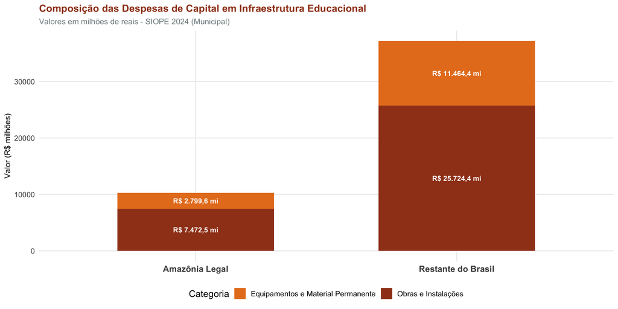

A composição das despesas de capital revela o perfil de investimento adotado pelos municípios de cada região. As despesas com obras e instalações, que englobam tanto construções novas quanto reformas e ampliações, tendem a representar a maior parcela do investimento. Já os equipamentos e material permanente incluem itens como mobiliário escolar, computadores e equipamentos de laboratório.

A proporção entre obras e equipamentos indica a fase do ciclo de investimento em que cada região se encontra: regiões com maior proporção de obras podem estar em fase de expansão ou recuperação da rede física, enquanto regiões com maior proporção de equipamentos podem estar em fase de modernização e reequipamento de unidades já existentes.

Na Amazônia Legal, as obras e instalações respondem por 72,7% do investimento em infraestrutura, contra 69,2% no restante do Brasil. Essa maior concentração em obras pode refletir a necessidade de construção e reforma de unidades escolares na região, onde muitas escolas ainda funcionam em condições precárias ou em instalações improvisadas.

# Investimento por Etapa de Ensino

Investimento em infraestrutura por etapa de ensino - 2024

| Etapa de Ensino | Amazônia Legal | % AL | Restante do Brasil | % RB | Comparação |
| --- | --- | --- | --- | --- | --- |
| Ensino Fundamental | R$ 7.021.466.808,38 | 68,5% | R$ 26.194.539.001,99 | 70,5% |  |
| Educação Infantil | R$ 3.138.348.882,51 | 30,6% | R$ 10.737.867.820,14 | 28,9% |  |
| Ensino Médio | R$ 83.541.200,71 | 0,8% | R$ 69.763.656,15 | 0,2% |  |
| Ensino Superior | R$ 120.511,70 | 0,0% | R$ 92.190.536,22 | 0,2% |  |
| Ensino Profissional | R$ 3.228.736,46 | 0,0% | R$ 49.090.595,94 | 0,1% |  |

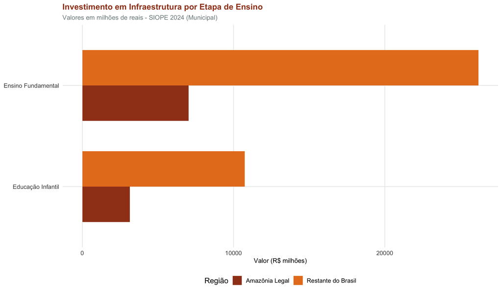

A distribuição do investimento em infraestrutura por etapa de ensino reflete as prioridades dos gestores municipais. Como os municípios são responsáveis prioritariamente pela educação infantil e pelo ensino fundamental, é natural que essas etapas concentrem a maior parte dos recursos.

A análise por subfunção orçamentária permite identificar se a alocação de recursos para infraestrutura acompanha a distribuição da demanda por vagas e por melhoria das condições físicas. Etapas com menor investimento relativo podem estar acumulando déficits de infraestrutura que comprometem a qualidade do ensino.

**Distribuição por etapa na Amazônia Legal:** O Ensino Fundamental recebeu R$ 7.021.466.808,38 em investimentos de infraestrutura, enquanto a Educação Infantil recebeu R$ 3.138.348.882,51. Essa distribuição deve ser avaliada à luz da expansão de vagas necessária em cada etapa e das condições físicas da rede existente.

# Investimento por Escola

Investimento em infraestrutura por escola - 2024

| Indicador | Amazônia Legal | Restante do Brasil | Comparação |
| --- | --- | --- | --- |
| Municípios na amostra | 795 | 4.711 |  |
| Total de escolas | 32.326 | 104.110 |  |
| Investimento médio por escola | R$ 373.853,40 | R$ 356.125,87 |  |
| Investimento mediano por escola | R$ 203.141,59 | R$ 205.762,55 |  |
| Percentil 25 | R$ 101.297,25 | R$ 82.327,93 |  |
| Percentil 75 | R$ 448.724,84 | R$ 458.424,63 |  |

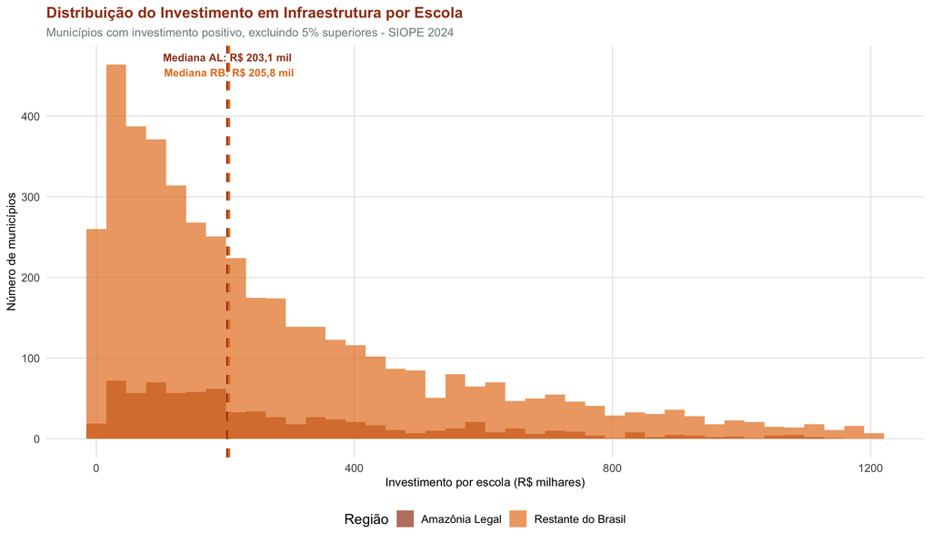

A análise por escola permite avaliar a intensidade do investimento de forma normalizada, controlando para o tamanho da rede municipal. A mediana do investimento por escola é um indicador mais robusto que a média, pois não é influenciada por valores extremos de municípios com investimentos muito concentrados em poucas obras de grande porte.

# Investimento por UF da Amazônia Legal

Investimento em infraestrutura por UF da Amazônia Legal - 2024

| UF | Investimento total | Municípios | Escolas | Investimento por município | Investimento por escola |
| --- | --- | --- | --- | --- | --- |
| MT | R$ 1.503.853.344,15 | 138 | 2.237 | R$ 10.897.488,00 | R$ 672.263,45 |
| PA | R$ 3.619.950.657,23 | 143 | 9.631 | R$ 25.314.340,26 | R$ 375.864,46 |
| MA | R$ 3.095.600.410,43 | 213 | 10.080 | R$ 14.533.335,26 | R$ 307.103,22 |
| TO | R$ 404.906.941,54 | 137 | 1.382 | R$ 2.955.525,12 | R$ 292.986,21 |
| RR | R$ 209.055.969,65 | 13 | 864 | R$ 16.081.228,43 | R$ 241.962,93 |
| AM | R$ 1.089.345.178,11 | 62 | 5.158 | R$ 17.570.083,52 | R$ 211.195,27 |
| RO | R$ 161.809.300,39 | 52 | 1.026 | R$ 3.111.717,32 | R$ 157.708,87 |
| AP | R$ 105.089.357,48 | 15 | 786 | R$ 7.005.957,17 | R$ 133.701,47 |
| AC | R$ 82.518.816,25 | 22 | 1.484 | R$ 3.750.855,28 | R$ 55.605,67 |

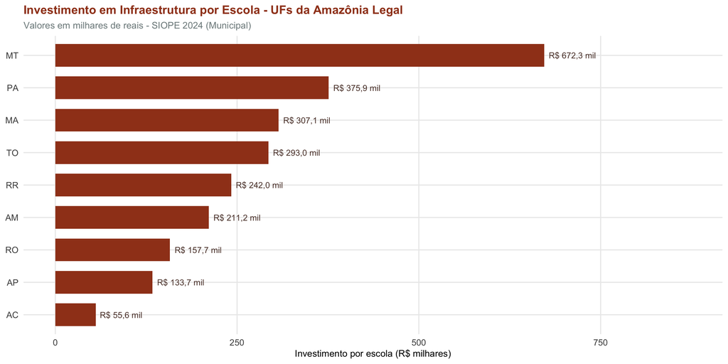

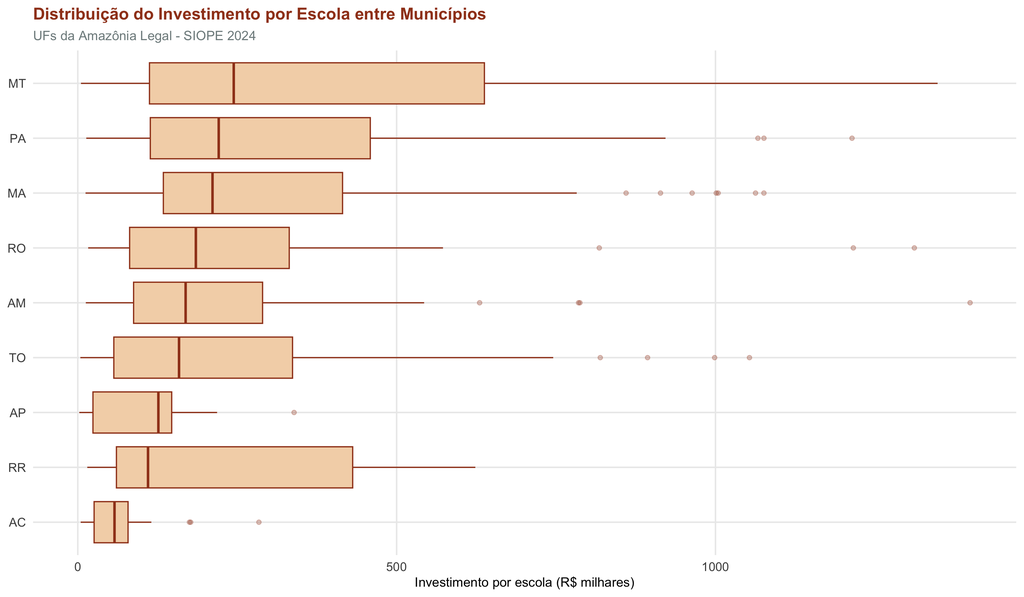

A análise por unidade da federação dentro da Amazônia Legal revela a heterogeneidade significativa dos investimentos em infraestrutura na região. As diferenças entre os estados refletem não apenas as diferentes capacidades fiscais dos municípios, mas também as distintas prioridades de política educacional e os diferentes estágios de desenvolvimento da rede escolar.

O boxplot da distribuição municipal mostra a dispersão interna de cada UF, indicando que mesmo dentro de um mesmo estado podem coexistir municípios com investimentos expressivos e municípios sem nenhum aporte de capital para infraestrutura. Essa heterogeneidade intrarregional é tão importante quanto a desigualdade entre regiões.

**Heterogeneidade interna:** O investimento por escola varia de R$ 672.263,45 em MT a R$ 55.605,67 em AC, uma razão de 12,1 vezes entre o maior e o menor valor. Essa dispersão demonstra que tratar a Amazônia Legal como um bloco homogêneo pode obscurecer realidades muito distintas.

# Análise de Carências de Infraestrutura (Censo Escolar)

Carências de infraestrutura nas escolas públicas - Censo Escolar 2025

[output not shown]

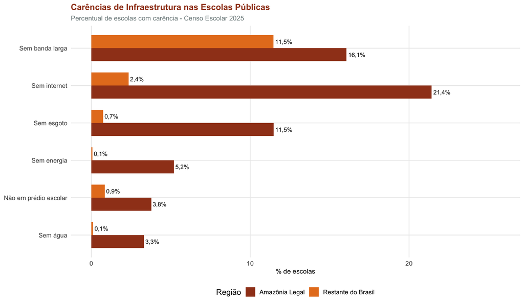

As carências de infraestrutura reveladas pelo Censo Escolar 2025 evidenciam o cenário desigual entre as regiões. A ausência de serviços básicos como água, energia e esgotamento sanitário afeta diretamente as condições de funcionamento das escolas e, consequentemente, a qualidade do processo educacional.

A conectividade, representada pelos indicadores de acesso à internet e banda larga, é particularmente relevante no contexto atual, em que recursos pedagógicos digitais e plataformas de aprendizagem online são cada vez mais integrados ao cotidiano escolar. Escolas sem acesso à internet ficam excluídas dessas possibilidades, ampliando a desigualdade de oportunidades educacionais.

**Déficit estrutural:** Na Amazônia Legal, 3,3% das escolas públicas não possuem abastecimento de água, 5,2% não têm energia elétrica e 21,4% não contam com acesso à internet. Esses indicadores demonstram que a região concentra carências de infraestrutura básica que exigem investimentos significativos e continuados.

# Cruzamento: Investimento vs. Carências

Cruzamento: investimento em infraestrutura vs. carências - UFs da Amazônia Legal

| UF | Escolas | Investimento por escola | Sem água (%) | Sem energia (%) | Sem internet (%) | Índice de carência |
| --- | --- | --- | --- | --- | --- | --- |
| AC | 1.484 | R$ 55.605,67 | 18,3% | 26,2% | 48,7% | 32,6 |
| AM | 5.158 | R$ 211.195,27 | 0,8% | 13,0% | 35,8% | 19,0 |
| RR | 864 | R$ 241.962,93 | 1,3% | 16,0% | 33,4% | 17,9 |
| AP | 786 | R$ 133.701,47 | 2,0% | 5,7% | 33,7% | 12,1 |
| PA | 9.631 | R$ 375.864,46 | 3,5% | 4,0% | 23,2% | 9,4 |
| MA | 10.080 | R$ 307.103,22 | 3,8% | 0,5% | 15,2% | 6,9 |
| RO | 1.026 | R$ 157.708,87 | 1,4% | 0,7% | 3,8% | 2,4 |
| TO | 1.382 | R$ 292.986,21 | 0,0% | 0,4% | 2,2% | 1,1 |
| MT | 2.237 | R$ 672.263,45 | 0,5% | 0,0% | 1,7% | 0,8 |

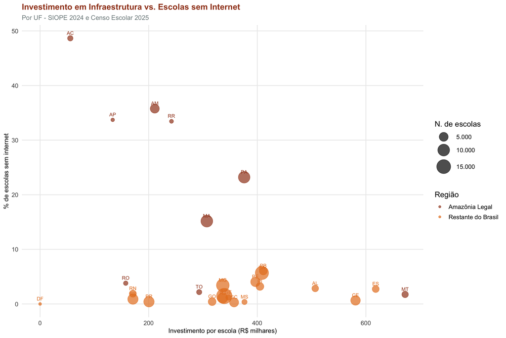

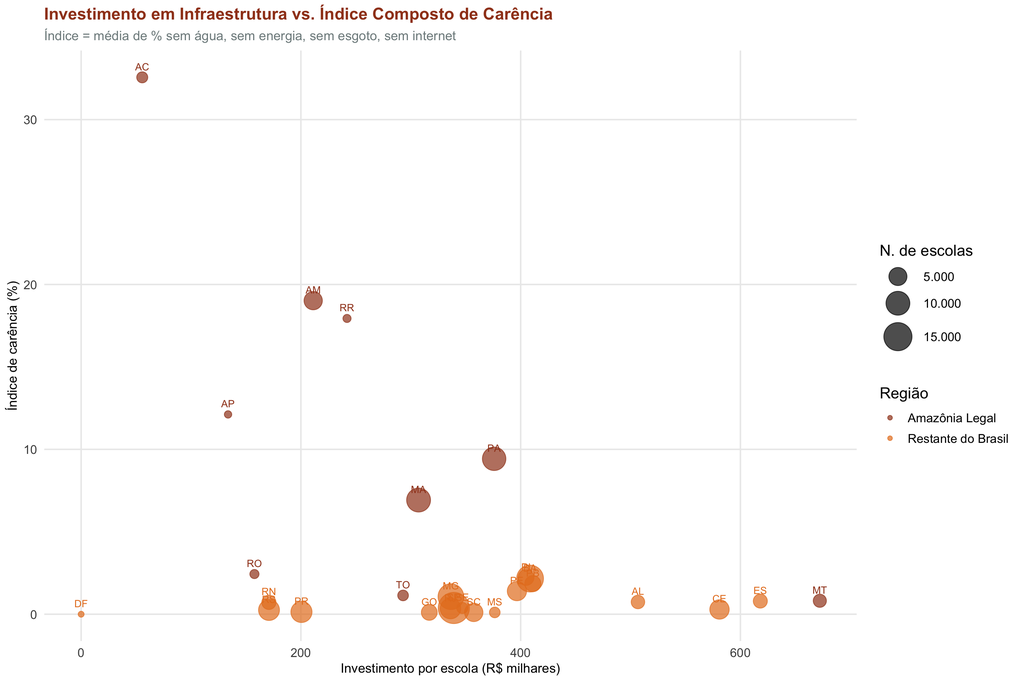

O cruzamento entre os dados de investimento em infraestrutura (SIOPE 2024) e as carências identificadas pelo Censo Escolar 2025 é o ponto central desta análise. Esse cruzamento permite identificar situações de dupla desvantagem: unidades da federação que, simultaneamente, investem pouco em infraestrutura e apresentam elevados índices de carência.

Nos gráficos de dispersão, os pontos ideais estariam no quadrante inferior direito (alto investimento, baixa carência). Pontos no quadrante superior esquerdo (baixo investimento, alta carência) representam as situações mais críticas, onde a insuficiência de recursos agrava as condições já precárias da infraestrutura escolar.

**Dupla desvantagem:** Os estados AC, AM, AP apresentam simultaneamente investimento por escola abaixo da mediana da Amazônia Legal e índice de carência acima da mediana. Essas UFs concentram as situações mais críticas e deveriam ser priorizadas em políticas de investimento em infraestrutura educacional.

# Detalhamento por Tipo de Obra

Detalhamento das despesas de capital - nível 4 (subitens) - 2024

| Tipo de despesa | Amazônia Legal | Restante do Brasil | Comparação |
| --- | --- | --- | --- |
| Mobiliário Em Geral | R$ 531.659.290,17 | R$ 1.398.730.011,76 |  |
| Obras Em Andamento | R$ 2.742.961.914,52 | R$ 7.432.674.587,10 |  |
| Outras Obras e Instalações | R$ 4.528.791.374,69 | R$ 17.630.749.771,22 |  |

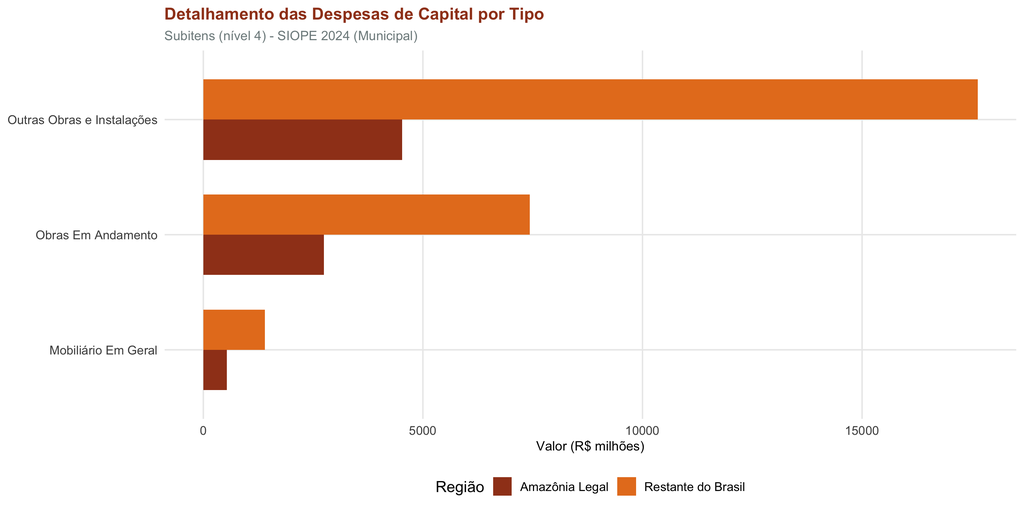

O detalhamento por tipo de obra permite distinguir entre construções novas (“Obras Em Andamento”) e outras intervenções (“Outras Obras e Instalações”), que incluem reformas, ampliações e adaptações. Essa distinção é relevante para entender a natureza do investimento: a predominância de “Obras Em Andamento” sugere expansão da rede, enquanto “Outras Obras” indica manutenção e adaptação do parque existente.

A categoria “Mobiliário Em Geral” reflete o investimento em carteiras, mesas, estantes e outros itens essenciais para o funcionamento das salas de aula. Embora seja um componente menor em valor absoluto, o mobiliário tem impacto direto no conforto e na funcionalidade do ambiente escolar.

**Perfil das obras na Amazônia Legal:** Das despesas com obras e instalações detalhadas no nível 4, 37,7% correspondem a “Obras Em Andamento” e 62,3% a “Outras Obras e Instalações”. A proporção de obras em andamento indica o ritmo de expansão e melhoria da rede física de escolas.

# Síntese Comparativa

Síntese comparativa - Amazônia Legal vs. Restante do Brasil

| Indicador | Amazônia Legal | Restante do Brasil | Razão AL/RB |
| --- | --- | --- | --- |
| Investimento total em infraestrutura | R$ 10.272.129.975,23 | R$ 37.188.810.004,71 | 0,28 |
| Investimento por município | R$ 12.920.918,21 | R$ 7.894.037,36 | 1,64 |
| Investimento por escola | R$ 314.632,75 | R$ 352.707,85 | 0,89 |
| Participação na despesa educacional | 4,8% | 3,1% | 1,55 |
| Escolas sem água (%) | 3,3% | 0,1% | 28,9 |
| Escolas sem energia (%) | 5,2% | 0,1% | 72,2 |
| Escolas sem esgoto (%) | 11,5% | 0,7% | 15,3 |
| Escolas sem internet (%) | 21,4% | 2,4% | 9,1 |
| Escolas sem banda larga (%) | 16,1% | 11,5% | 1,4 |
| Escolas fora de prédio escolar (%) | 3,8% | 0,9% | 4,4 |

A tabela síntese permite visualizar de forma consolidada a dupla dimensão da desigualdade em infraestrutura educacional. As quatro primeiras linhas apresentam os indicadores de investimento (SIOPE), enquanto as seis últimas mostram os indicadores de carência (Censo Escolar). A coluna “Razão AL/RB” expressa quantas vezes o valor da Amazônia Legal é maior (ou menor) que o do restante do Brasil.

A análise integrada desses indicadores revela um paradoxo recorrente na educação brasileira: as regiões com maiores carências de infraestrutura são precisamente aquelas com menor capacidade de investimento. Esse ciclo de desigualdade só pode ser rompido com políticas redistributivas que canalizem recursos adicionais para as regiões mais necessitadas.

**Principais achados:**

- A Amazônia Legal apresenta carências de infraestrutura significativamente maiores que o restante do Brasil em todas as dimensões analisadas (água, energia, esgoto, internet, instalações físicas).
- O investimento por escola tende a ser inferior ao do restante do país, agravando o ciclo de desigualdade estrutural.
- Dentro da Amazônia Legal, há grande heterogeneidade entre os estados, com algumas UFs concentrando as piores condições e os menores investimentos simultaneamente.
- A ausência de investimentos de capital em parcela expressiva dos municípios indica que muitas redes municipais operam sem nenhum aporte para melhoria das condições físicas das escolas.

Esses resultados reforçam a necessidade de mecanismos de financiamento diferenciados que considerem as especificidades territoriais da Amazônia Legal e priorizem os municípios com maiores carências de infraestrutura.

# Metodologia

## Fontes de Dados

Este relatório utiliza quatro fontes de dados para analisar os investimentos municipais em infraestrutura educacional e as condições físicas das escolas.

A primeira fonte é a base de **Despesas Detalhadas do SIOPE** (Despesas_Siope_2024.csv), que contém os registros individuais de despesa por item, organizados em uma estrutura hierárquica. As variáveis relevantes incluem: TIPO (Municipal ou Estadual), COD_MUNI (código do município com 6 dígitos), SIG_UF (sigla da UF), NOM_COLU (estágio de execução: “Desp. Pagas”, “Desp. Empenhadas”, “Desp. Liquidadas”, “Dotação Atualizada”), NOM_ITEM (descrição textual do item de despesa), NUM_NIVE (nível hierárquico do item, de 1 a 5), COD_SUBF (código da subfunção orçamentária), COD_EXIB (código de exibição que identifica a natureza da despesa) e VAL_DECL (valor declarado em formato texto com vírgula decimal).

A segunda fonte é a base de **Despesas por Função da Educação** (Despesas_Funcao_Educacao_Siope_2024.csv), utilizada para calcular o total de gastos educacionais municipais por subfunção e assim determinar a participação percentual das despesas de infraestrutura no total. A variável VAL_DESP_PAGA contém as despesas pagas por subfunção.

A terceira fonte é o **Censo Escolar 2025** (Tabela_Escola_2025_geocoded.csv), versão geocodificada da tabela de escolas, contendo indicadores binários de infraestrutura física: IN_AGUA_INEXISTENTE, IN_ENERGIA_INEXISTENTE, IN_ESGOTO_INEXISTENTE (indicam ausência do serviço), IN_INTERNET, IN_BANDA_LARGA (indicam presença de conectividade), IN_AGUA_REDE_PUBLICA, IN_ENERGIA_REDE_PUBLICA, IN_ESGOTO_REDE_PUBLICA (indicam provisão via rede pública), e variáveis de tipo de local de funcionamento (IN_LOCAL_FUNC_PREDIO_ESCOLAR, IN_LOCAL_FUNC_GALPAO, IN_LOCAL_FUNC_OUTROS).

A quarta fonte é o arquivo **municipios_amazonia_legal.csv**, com a lista dos 772 municípios da Amazônia Legal e seus códigos IBGE de 7 dígitos.

## Pré-processamento

Os arquivos CSV do SIOPE utilizam separador ponto-e-vírgula (;) e os campos numéricos seguem o padrão brasileiro com vírgula decimal. A conversão é feita por `as.numeric(gsub(",", ".", VAL_DECL))`, armazenando o resultado na coluna VAL. O arquivo de Despesas Detalhadas é filtrado para TIPO = “Municipal” e a classificação regional é feita diretamente pela sigla da UF, verificando se pertence ao vetor das 9 UFs amazônicas.

O Censo Escolar é filtrado para escolas em atividade (TP_SITUACAO_FUNCIONAMENTO = 1) e públicas (TP_DEPENDENCIA entre 1 e 3, correspondendo a Federal, Estadual e Municipal). A classificação regional também é feita pela sigla da UF. Para compatibilizar os códigos de município entre Censo (7 dígitos IBGE) e SIOPE (6 dígitos), cria-se a variável COD_MUNI_6 truncando os 6 primeiros dígitos do código IBGE.

## Classificação de Itens de Infraestrutura

Os itens de despesa do SIOPE são organizados em uma estrutura hierárquica indicada pela variável NUM_NIVE, onde níveis mais altos representam totais que incluem os subitens de níveis inferiores. Para identificar as despesas de infraestrutura dentre todas as despesas detalhadas, utilizam-se expressões regulares (regex) sobre o campo textual NOM_ITEM, combinadas com o nível hierárquico via `fcase()`.

No nível 3 (totais agregados), são classificadas três categorias: “Obras e Instalações” (NOM_ITEM iniciando com “Obras e Instala”, NUM_NIVE = 3), que engloba construção, reforma e ampliação de edificações escolares; “Equipamentos e Material Permanente” (NOM_ITEM iniciando com “Equipamentos e Material Perm”, NUM_NIVE = 3), que inclui mobiliário, computadores e equipamentos de laboratório; e “Aquisição de Imóveis” (NOM_ITEM contendo “Aquisic” seguido de “Im”, NUM_NIVE = 3), referente a compra de terrenos e edificações.

No nível 4 (subitens), identificam-se categorias mais detalhadas para fins descritivos: “Obras Em Andamento”, “Outras Obras e Instalações” e “Mobiliário Em Geral”. Registros cujo NOM_ITEM não corresponde a nenhum padrão recebem NA e são excluídos do dataset de infraestrutura.

Para os totais gerais e cálculos de participação, utilizam-se exclusivamente os itens de nível 3 (dataset infra_agg), evitando dupla contagem que ocorreria se itens de nível 3 (que já incluem os subitens) fossem somados com os itens de nível 4. O detalhamento de nível 4 é utilizado apenas na seção descritiva de tipos de obra.

Cada item de infraestrutura é associado a uma etapa de ensino pela variável COD_SUBF (código da subfunção orçamentária), mapeada para nomes legíveis por uma tabela de referência: 361 = Ensino Fundamental, 365 = Educação Infantil, 366 = EJA, 367 = Educação Especial, 362 = Ensino Médio, 122 = Administração Geral, entre outras.

## Normalização e Indicadores

O investimento em infraestrutura é normalizado por duas métricas: por município (total investido dividido pelo número de municípios com dados no SIOPE) e por escola (total investido dividido pelo número de escolas públicas ativas no Censo Escolar 2025). A normalização por escola é a principal métrica de comparação, pois permite avaliar o esforço de investimento em relação ao tamanho da rede escolar de cada região.

A participação das despesas de infraestrutura no total educacional é calculada pela razão entre o total de despesas de capital classificadas como infraestrutura (nível 3) e o total de despesas pagas da Função 12 (Educação) obtido da base de Despesas por Subfunção.

O índice composto de carência infraestrutural é calculado como a média aritmética simples de quatro indicadores municipais: percentual de escolas sem água (IN_AGUA_INEXISTENTE = 1), percentual sem energia (IN_ENERGIA_INEXISTENTE = 1), percentual sem esgotamento sanitário (IN_ESGOTO_INEXISTENTE = 1) e percentual sem acesso à internet (IN_INTERNET = 0, invertendo a lógica pois a variável indica presença). Esse índice varia de 0 (nenhuma carência) a 100 (carência total em todas as dimensões) e permite uma visão integrada das múltiplas dimensões de precariedade.

A análise de cruzamento entre investimento e carência por UF permite avaliar se os estados com maiores déficits de infraestrutura são também os que mais investem em capital fixo (o que indicaria um esforço de recuperação) ou se, pelo contrário, a insuficiência de investimento agrava as carências existentes.

## Limitações

Os dados de despesas do SIOPE são autodeclaratórios e a classificação de itens de infraestrutura depende da padronização dos nomes de item (NOM_ITEM) pelos entes federados. Divergências na nomenclatura podem resultar em subestimação de categorias específicas. A análise foca exclusivamente em despesas municipais pagas, excluindo investimentos estaduais e federais em infraestrutura escolar, que podem ser significativos em estados onde a rede estadual é predominante.

A normalização por escola trata todas as escolas como equivalentes, independentemente do porte (número de alunos, salas de aula). Uma escola com 50 alunos e outra com 2.000 têm o mesmo peso no denominador, o que pode distorcer a comparação em regiões com distribuições de porte escolar distintas.

A defasagem temporal entre SIOPE (2024) e Censo Escolar (2025) é considerada aceitável para fins de comparação regional, mas significa que os indicadores de carência refletem o estado das escolas um ano após os investimentos analisados.